# Отчет по домашней работе №2

## Набор данных 2

```r
# install.packages("pacman")
pacman::p_load(readxl, ggplot2, dplyr, nortest, car, tidyverse, scales, emmeans, multcomp, multcompView, gtsummary, knitr)
```

1. Загрузите необходимые данные из файла hw2.shelepin.data.xlsx

```r
hw2_data <- read_excel("hw2.shelepin.data.xlsx", sheet = "carab")
kable(summary(hw2_data))
```

|  | length | association |
| --- | --- | --- |
|  | Min. : 5.870 | Length:88 |
|  | 1st Qu.: 8.732 | Class :character |
|  | Median : 9.639 | Mode :character |
|  | Mean : 9.688 | NA |
|  | 3rd Qu.:10.680 | NA |
|  | Max. :13.873 | NA |

2. Рассчитайте описательные статистики и заполните таблицу:

```r
result <- hw2_data %>%
  group_by(association) %>%
  summarise(
    Среднее = mean(length),
    Дисперсия = var(length),
    Стандартное_отклонение = sd(length),
    Объем_выборки = n(),
    Минимум = min(length),
    Максимум = max(length)
  )
kable(result)
```

| association | Среднее | Дисперсия | Стандартное_отклонение | Объем_выборки | Минимум | Максимум |
| --- | --- | --- | --- | --- | --- | --- |
| Березняк разнотравно-осоковый | 10.586647 | 0.7179520 | 0.8473205 | 17 | 9.165 | 12.197 |
| Буковник копытне-снытевый | 9.097933 | 0.4941845 | 0.7029826 | 15 | 7.877 | 10.244 |
| Дубняк снытево-разнотравный | 11.931692 | 0.8896662 | 0.9432212 | 13 | 10.638 | 13.873 |
| Кленовник высокотравно-снытевый | 10.032462 | 0.4085063 | 0.6391450 | 13 | 8.689 | 10.936 |
| Кленовник снытево-осоково-разнотравный | 8.526235 | 1.2382231 | 1.1127547 | 17 | 6.744 | 10.432 |
| Осинник подмаренниково-снытевый | 8.128154 | 1.4054218 | 1.1855049 | 13 | 5.870 | 9.498 |

3. Преобразуйте фактор таким образом, чтобы категории следовали в порядке роста средней активности амилазы. Переименуйте имена категорий для более компактного отображения на графиках (сократите имена, можно использовать аббревиатуры)

```r
means <- aggregate(length ~ association, data = hw2_data, FUN = mean)
means <- means[order(means$length), ]

abbreviations <- c(
  "Березняк разнотравно-осоковый" = "БРО",
  "Кленовник снытево-осоково-разнотравный" = "КСОР",
  "Буковник копытне-снытевый" = "БКС",
  "Осинник подмаренниково-снытевый" = "ОПС",
  "Дубняк снытево-разнотравный" = "ДСР",
  "Кленовник высокотравно-снытевый" = "КВС"
)

hw2_data$association_n <- factor(hw2_data$association,
                           levels = means$association,
                           labels = abbreviations[means$association])

# Проверяем результат
levels(hw2_data$association_n)
```

```
## [1] "ОПС"  "КСОР" "БКС"  "КВС"  "БРО"  "ДСР"
```

```r
result <- hw2_data %>%
  group_by(association_n) %>%
  summarise(
    Среднее = mean(length),
    Дисперсия = var(length),
    Стандартное_отклонение = sd(length),
    Объем_выборки = n(),
    Минимум = min(length),
    Максимум = max(length)
  )
kable(result)
```

| association_n | Среднее | Дисперсия | Стандартное_отклонение | Объем_выборки | Минимум | Максимум |
| --- | --- | --- | --- | --- | --- | --- |
| ОПС | 8.128154 | 1.4054218 | 1.1855049 | 13 | 5.870 | 9.498 |
| КСОР | 8.526235 | 1.2382231 | 1.1127547 | 17 | 6.744 | 10.432 |
| БКС | 9.097933 | 0.4941845 | 0.7029826 | 15 | 7.877 | 10.244 |
| КВС | 10.032462 | 0.4085063 | 0.6391450 | 13 | 8.689 | 10.936 |
| БРО | 10.586647 | 0.7179520 | 0.8473205 | 17 | 9.165 | 12.197 |
| ДСР | 11.931692 | 0.8896662 | 0.9432212 | 13 | 10.638 | 13.873 |

4. Сформируйте модель дисперсионного анализа исследуемой зависимости

```r
fit <- lm(length ~ association_n, data = hw2_data)
summary(fit)
```

```
##
## Call:
## lm(formula = length ~ association_n, data = hw2_data)
##
## Residuals:
##      Min       1Q   Median       3Q      Max
## -2.25815 -0.61735  0.00233  0.66135  1.94131
##
## Coefficients:
##                   Estimate Std. Error t value Pr(>|t|)
## (Intercept)         8.1282     0.2575  31.571  < 2e-16 ***
## association_nКСОР   0.3981     0.3420   1.164  0.24783
## association_nБКС    0.9698     0.3518   2.757  0.00719 **
## association_nКВС    1.9043     0.3641   5.230 1.27e-06 ***
## association_nБРО    2.4585     0.3420   7.188 2.76e-10 ***
## association_nДСР    3.8035     0.3641  10.446  < 2e-16 ***
## ---
## Signif. codes:  0 '***' 0.001 '**' 0.01 '*' 0.05 '.' 0.1 ' ' 1
##
## Residual standard error: 0.9283 on 82 degrees of freedom
## Multiple R-squared:  0.6654, Adjusted R-squared:  0.645
## F-statistic: 32.61 on 5 and 82 DF,  p-value: < 2.2e-16
```

5. Проанализируйте характер распределения остатков. Примените три критерия согласия. Приведите p-значения и сделайте итоговый вывод. Проведите анализ гомогенности дисперсии количественной переменной. Приведите название процедуры, p-значение и сделайте вывод.

```r
residuals <- residuals(fit)

# 1. Критерий Шапиро-Уилка
shapiro_test <- shapiro.test(residuals)
# 2. Критерий Лиллиефорса
lillie <- lillie.test(residuals)
# 3. Критерий Андерсона-Дарлинга
ad_test <- ad.test(residuals)
```

```r
p_values <- data.frame(
  Test = c("Шапиро-Уилка", "Лиллиефорса", "Андерсона-Дарлинга"),
  `p-value` = c(shapiro_test$p.value, lillie$p.value, ad_test$p.value)
)
kable(p_values, col.names = c("Критерий", "p-value"))
```

| Критерий | p-value |
| --- | --- |
| Шапиро-Уилка | 0.8572083 |
| Лиллиефорса | 0.7893374 |
| Андерсона-Дарлинга | 0.8717920 |

Поскольку все три теста показывают p > 0.05 (0.85, 0.78 и 0.87 соответственно), распределение остатков **можно считать нормальным**.

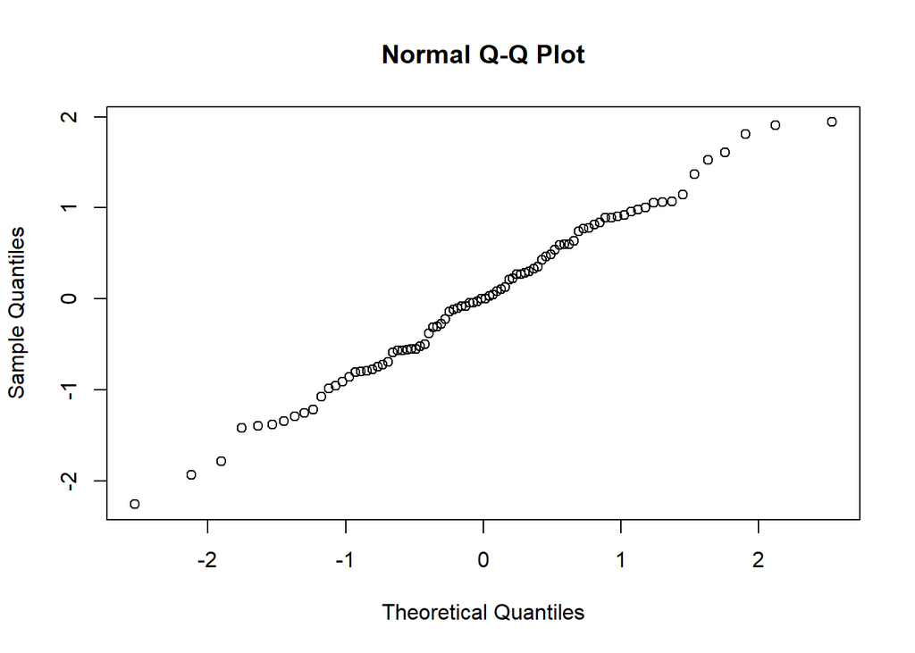

```r
# Q-Q график
qqnorm(residuals)
```

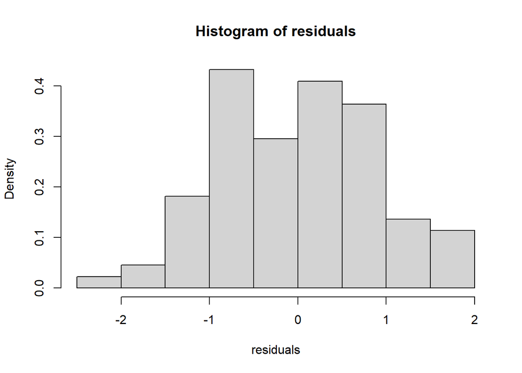

```r
# Гистограмма остатков
hist(residuals, freq = FALSE)
```

Наблюдается **распределение, близкое к нормальному**.

Тест на гомогенность дисперсий:

```r
leveneTest(length ~ association_n, hw2_data)
```

```
## Levene's Test for Homogeneity of Variance (center = median)
##       Df F value Pr(>F)
## group  5  1.4893 0.2023
##       82
```

Дисперсии гомогенны, если p-value > 0.05.  
F = 1.4893, p > 0.2 – **дисперсии гомогенны**.

6. Проведите анализ влияния типа местообитания на длину жужелиц с использованием процедуры, соответствующей характеру распределения данных. Заполните таблицу и сделайте вывод.

ANOVA (ANalysis Of VAriance)

```r
anova_res <- anova(fit)
anova_res
```

```
## Analysis of Variance Table
##
## Response: length
##               Df  Sum Sq Mean Sq F value    Pr(>F)
## association_n  5 140.513 28.1026  32.612 < 2.2e-16 ***
## Residuals     82  70.661  0.8617
## ---
## Signif. codes:  0 '***' 0.001 '**' 0.01 '*' 0.05 '.' 0.1 ' ' 1
```

```r
kable(anova_res)
```

|  | Df | Sum Sq | Mean Sq | F value | Pr(>F) |
| --- | --- | --- | --- | --- | --- |
| association_n | 5 | 140.51322 | 28.1026437 | 32.61251 | 0 |
| Residuals | 82 | 70.66052 | 0.8617136 | NA | NA |

“association_n” оказывает **статистически значимое влияние** на “length”: p-значение крайне мало (< 2,2e-16), что означает, что различия в средней “length” между разными уровнями “association_n” вряд ли возникли случайно.  
F-value 32,612 указывает на то, что **изменчивость между группами намного больше, чем изменчивость внутри групп**, что еще больше подтверждает вывод о том, что “association_n” является значимым предиктором “length”

Вывод: Результаты ANOVA показывают, что “association_n” существенно влияет на “length”. Существуют значимые различия в средней “length” для разных уровней “association_n”.

7. Проведите попарные сравнения средних с применением наиболее мощной процедуры, соответствующей распределению данных. Какие пары выборок отличаются по средней длине жужелиц?

Воспользуемся **t-критерием Стьюдента**:

```r
pairwise.t.test(hw2_data$length, hw2_data$association_n)
```

```
##
##  Pairwise comparisons using t tests with pooled SD
##
## data:  hw2_data$length and hw2_data$association_n
##
##      ОПС     КСОР    БКС     КВС     БРО
## КСОР 0.25762 -       -       -       -
## БКС  0.03595 0.25762 -       -       -
## КВС  1.3e-05 0.00022 0.03792 -       -
## БРО  3.3e-09 7.3e-08 0.00016 0.25762 -
## ДСР  1.5e-15 1.3e-14 7.0e-11 1.3e-05 0.00105
##
## P value adjustment method: holm
```

Пары выборок **значительно** отличаются по средней длине, если p-value < 0.05. Это пары:

ОПС-БКС  
ОПС-КВС  
ОПС-БРО  
ОПС-ДРС  
КСОР-КВС  
КСОР-БРО  
КСОР-ДСР  
БКС-КВС  
БКС-БРО  
БКС-ДСР  
КВС-ДСР  
БРО-ДСР

8. Составьте систему компактных буквенных обозначений, отражающих значимость попарных сравнений.

```r
model <- lm(length ~ association_n, data = hw2_data)
model_means <- emmeans(object = model,
                       specs = "association_n")
model_means_cld <- cld(object = model_means,
                       Letters = letters,
                       alpha = 0.05)
model_means_cld
```

```
##  association_n emmean    SE df lower.CL upper.CL .group
##  ОПС             8.13 0.257 82     7.62     8.64  a
##  КСОР            8.53 0.225 82     8.08     8.97  a
##  БКС             9.10 0.240 82     8.62     9.57  ab
##  КВС            10.03 0.257 82     9.52    10.54   bc
##  БРО            10.59 0.225 82    10.14    11.03    c
##  ДСР            11.93 0.257 82    11.42    12.44     d
##
## Confidence level used: 0.95
## P value adjustment: tukey method for comparing a family of 6 estimates
## significance level used: alpha = 0.05
## NOTE: If two or more means share the same grouping symbol,
##       then we cannot show them to be different.
##       But we also did not show them to be the same.
```

9. Для визуализации результатов попарных сравнений постройте столбчатую диаграмму с доверительными интервалами и компактными буквенными обозначениями. Стоблцы должны быть залиты разными цветами. Вставьте полученный график в итоговый отчет.

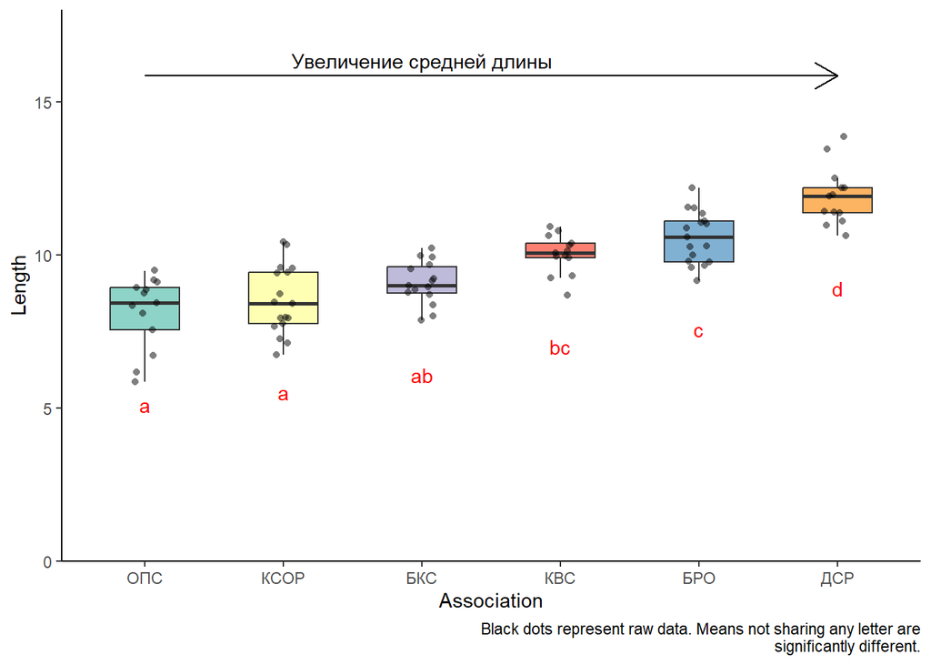

```r
model_means_cld <- model_means_cld %>%
  mutate(association_n = fct_reorder(association_n, emmean))

hw2_data <- hw2_data %>%
  mutate(association_n = fct_relevel(association_n, levels(model_means_cld$association_n)))

ggplot() +
  scale_y_continuous(
    name = "Length",
    limits = c(0, NA),
    breaks = pretty_breaks(),
    expand = expansion(mult = c(0,0.1))
  ) +
  scale_x_discrete(
    name = "Association"
  ) +
  theme_classic() +
  geom_boxplot(
    data = hw2_data,
    aes(y = length, x = association_n, fill = association_n),
    width = 0.5,
    outlier.shape = NA
  ) +
  scale_fill_brewer(palette = "Set3") +
  geom_point(
    data = hw2_data,
    aes(y = length, x = association_n),
    shape = 16,
    alpha = 0.5,
    position = position_jitter(width = 0.1)
  ) +
  geom_text(
    data = model_means_cld,
    aes(
      y = emmean,
      x = association_n,
      label = str_trim(.group)
    ),
    position = position_nudge(x = 0, y = -3),
    hjust = 0.5,
    color = "red"
  ) +
  annotate("segment",
           x = 1,
           xend = length(unique(hw2_data$association_n)),
           y = max(hw2_data$length) + 2,
           yend = max(hw2_data$length) + 2,
           arrow = arrow(length = unit(0.5, "cm"))) +
  annotate("text",
           x = length(unique(hw2_data$association_n))/2,
           y = max(hw2_data$length) + 2.5,
           label = "Увеличение средней длины") +
  theme(legend.position = "none") +
  labs(
    caption = str_wrap("Black dots represent raw data. Means not sharing any letter are significantly different.", width = 70)
  )
```